# Hypergeometric test in R

Michael Jahn

16 Oktober, 2024

## Hypergeometric test

### Background

The hypergeometric test is a simple statistical procedure to test for over- or under-representation of items (groups) in a defined global set. For example, if a global set consists of 50 black and 50 white balls, and 20 balls are randomly selected from this set, what is the probability that 17 white balls and only 3 black balls are chosen? The hypergeometric test can answer such questions by using the probability function of the [hypergeometric distribution](https://en.wikipedia.org/wiki/Hypergeometric_distribution). This distribution is highly related to the binomial distribution which uses a similar definition but *with replacement*, instead of *without*.

This document walks through one example where the hypergeometric test is used to determine gene enrichment for pathways of the [subtiwiki pathway categories](http://www.subtiwiki.uni-goettingen.de/v3/category/ for the bacterium *Bacillus subtilis*.

### Libraries and test data

- Install `Category` package from Bioconductor

```r
BiocManager::install("Category")
```

- load required libraries

```r
suppressPackageStartupMessages({
  library(Category)
  library(tidyverse)
})
```

- import category test data (from subtiwiki)

```r
df_subtiwiki <- read_csv("../data/geneCategories-2022-09-02.csv",
  name_repair = function(x) str_replace_all(x, " ", "_"),
  show_col_types = FALSE)

head(df_subtiwiki)
```

| category_id | category | gene_locus | gene_name |
| --- | --- | --- | --- |
| SW.3.1.1 | DNA replication | BSU_00010 | NA |
| SW.6.1 | Essential genes | BSU_00010 | NA |
| SW.3.1.1 | DNA replication | BSU_00020 | NA |
| SW.6.1 | Essential genes | BSU_00020 | NA |
| SW.3.1.5.7 | Mismatch repair (MMR) | BSU_00020 | NA |
| SW.3.3.1.6 | Ribosome assembly | BSU_00030 | NA |

- convert dataframe into a nested list format

```r
subti_categories <- df_subtiwiki %>%
  mutate(category = str_sub(category, 1, 25)) %>%
  select(category, gene_locus) %>%
  group_by(category) %>%
  summarize(gene_locus = list(gene_locus)) %>%
  deframe()

head(subti_categories, n = 3)
```

```
$`6S RNA`
[1] "BSU_misc_RNA_32" "BSU_misc_RNA_41"

$`A/P endonucleases`
[1] "BSU_22340" "BSU_25130" "BSU_40880"

$`ABC transporters for the `
 [1] "BSU_01610" "BSU_01610" "BSU_01620" "BSU_01620" "BSU_01630" "BSU_01630" "BSU_03800" "BSU_03800"
 [9] "BSU_03810" "BSU_03810" "BSU_03820" "BSU_03820" "BSU_03830" "BSU_03830" "BSU_07490" "BSU_07490"
[17] "BSU_07500" "BSU_07500" "BSU_07510" "BSU_07510" "BSU_07520" "BSU_07520" "BSU_08440" "BSU_08440"
[25] "BSU_08450" "BSU_08450" "BSU_08460" "BSU_08460" "BSU_10330" "BSU_10330" "BSU_32940" "BSU_32940"
[33] "BSU_33290" "BSU_33290" "BSU_33300" "BSU_33300" "BSU_33310" "BSU_33310" "BSU_33320" "BSU_33320"
[41] "BSU_39610" "BSU_39610"
```

### Prepare input data

- **assayed**: gene sets that were tested in an experiment, usually all genes/pathways in the universe
- example: we select a subset of 20 subtiwiki categories with each more than 20 genes

```r
assayed <- subti_categories[lapply(subti_categories, length) >= 20][1:20]
```

- **significant**: genes within the assayed set that were observed, or fall below a sign. threshold
- example: we select 10% of genes as significant

```r
significant <- lapply(assayed, function(x) sample(x, length(x)/10))
```

- **universe**: all unique gene names

```r
universe = assayed %>%
  unlist(use.names = FALSE) %>%
  unique
```

### Run test and inspect results

- run hypergeometric test using `hyperg` function from `Categories`

```r
result <- hyperg(
  assayed,
  significant,
  universe,
  representation = "over"
)

result <- mutate(result, across(everything(), unlist))
```

- expected result: all p-values are very similar (no enrichment of a specific pathway)

```r
head(result)
```

|  | assayed | significant | universe | representation | p | odds | expected |
| --- | --- | --- | --- | --- | --- | --- | --- |
| ABC transporters for the | 42 | 4 | 846 | over | 0.1493603 | 2.121884 | 2.0851064 |
| APC superfamily | 22 | 2 | 846 | over | 0.1089703 | 4.020000 | 0.5721040 |
| Acquisition of iron / Oth | 44 | 4 | 846 | over | 0.1900607 | 1.905000 | 2.2884161 |
| Additional germination pr | 31 | 3 | 846 | over | 0.1000165 | 3.011480 | 1.1359338 |
| Additional proteins invol | 29 | 2 | 846 | over | 0.2616911 | 2.167353 | 0.9940898 |
| Aminoacyl-tRNA synthetase | 28 | 2 | 846 | over | 0.2361042 | 2.343195 | 0.9267139 |

- what happens if one pathway has more than 10% sign. genes?

```r
significant[[1]] <- sample(assayed[[1]], 20)
```

- run hypergeometric test again and inspect result
- the first (modified) pathway has lower p-value and higher odds

```r
result2 <- hyperg(
    assayed,
    significant,
    universe,
    representation = "over"
  ) %>%
  mutate(across(everything(), unlist))

head(result2)
```

|  | assayed | significant | universe | representation | p | odds | expected |
| --- | --- | --- | --- | --- | --- | --- | --- |
| ABC transporters for the | 42 | 20 | 846 | over | 1.140491e-09 | 13.857143 | 2.0851064 |
| APC superfamily | 22 | 2 | 846 | over | 1.089703e-01 | 4.020000 | 0.5721040 |
| Acquisition of iron / Oth | 44 | 4 | 846 | over | 1.900607e-01 | 1.905000 | 2.2884161 |
| Additional germination pr | 31 | 3 | 846 | over | 1.000165e-01 | 3.011480 | 1.1359338 |
| Additional proteins invol | 29 | 2 | 846 | over | 2.616911e-01 | 2.167353 | 0.9940898 |
| Aminoacyl-tRNA synthetase | 28 | 2 | 846 | over | 2.361042e-01 | 2.343195 | 0.9267139 |

### P-value adjustment

- p-values from testing hundreds to thousands of pathways can be highly inflated
- the chance of discovering false positive correlations increases with the number of carried out tests
- to correct for multiple hypothesis testing, p-value adjustment is often advisable
- simply speaking, p-value adjustment works by correcting the observed p-value distribution depending on the number of tests that were carried out
- various methods are available, differing in their conservativeness
- a good option to start with is usually the Benjamini-Hochberg method, implemented in R with `stats::p.adjust(p, method = "BH")`
- the example below shows how p-values increase (become less “significant”) after adjustment

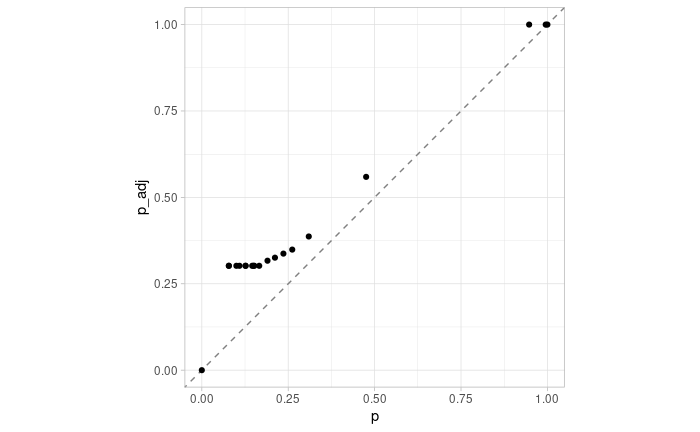

```r
result2 <- mutate(result2, p_adj = p.adjust(p, method = "BH"))

result2 %>%
  ggplot(aes(x = p, y = p_adj)) +
  geom_abline(slope = 1, intercept = 0, linetype = 2, color = grey(0.5)) +
  geom_point() +
  theme_light() +
  theme(aspect.ratio = 1.0)
```

### Interpretation

The output table from the gene enrichment function can be interpreted as follows:

- `p`: column with *un-adjusted* p-values
- `odds`: intermediate statistic from hypergeometric test – if we picture an urn containing genes from the universe, genes annotated at a given category are white (`W`) and the rest black (`B`), then odds ratio is `(W_drawn * (B - B_drawn)) / (B_drawn * (W - W_drawn))`
- `expected`: the number of expected genes from the assayed group